# Characterizing Reactions using MINVAL

Daniel Osorio, Janneth Gonzalez and Andres Pinzon

### Characterize Reactions

Characterize the stoichiometric reactions of a metabolic model is a required and time-consuming work. The **MINVAL** package includes the `characterizeReactions` function to characterize the stoichiometric functions and metabolites by compartment.

To load the **MINVAL** package just type:

```r
library(minval)
```

To show the potential use of the `characterizeReactions` function of the **MINVAL** package the Human Metabolic Reconstruction (RECON 2.04) was included in a human-readable format. To load it just type:

```r
RECON <- read.csv(system.file("extdata", "rRECON2.csv",
                              package = "minval"))
dim(RECON)
```

```
## [1] 7441    8
```

The `characterizeReactions` function requires a set of stoichiometric reactions as input. The given stoichiometric reactions must have the following mandatory characteristics:

- Arrows symbols must be given in the form `'=>'` or `'<=>'` (Inverse arrow symbols `'<='` or other types as: `'-->'`, `'<==>'`, `'->'` will not be parsed and will lead to errors.)
- Arrow symbols and plus signs (`+`) must be surrounded by a space character.
- Stoichiometric coefficients must be surrounded by a space character and not by parentheses.
- Each metabolite must have only one stoichiometric coefficient, substituents must be joined to metabolite name by a hyphen (`-`) symbol.
- Exchange reactions must have only one metabolite before arrow symbol.
- Compartments must be given between square brackets (`[compartment]`) joined at the end of metabolite name.

The `characterizeReactions` function: - Counts the number of reactions - Computes the relative frequency of each reaction type (transport, exchange and compartmentalized) - Computes the relative frequency of reactions by compartment - Counts the number of unique metabolites - Computes the relative frequency of metabolites by compartment

Finally the `characterizeReactions` function returns all these information as a labeled list. To characterize a set of stoichiometric reactions just type:

```r
RECONcharacteristics <- characterizeReactions(reactionList = RECON$REACTION)
RECONcharacteristics
```

```
## $nReactions
## [1] 7441
##
## $rType
##
## Compartmentalized reaction          Exchange reaction
##                  55.825830                   9.420777
##         Transport reaction
##                  34.753393
##
## $cReaction
##
##         c         e         g         l         m         n         r         x
## 24.593469  1.760516  3.628545  2.983470  9.958339  1.666443  6.208843  5.026206
##
## $nMetabolites
## [1] 5063
##
## $cMetabolites
##
##         c         e         g         l         m         n         r         x
## 37.092633 12.680229  6.261110  5.964843 14.892356  3.258937 11.258147  8.591744
```

Computed values can be easy plotted as follows:

#### Type of Reactions

Metabolic models generally includes three types of reactions:

- **Compartmentalized reactions:** Reactions in where all involved metabolites (all reactants and products) were assigned to the same compartment. e.g. `h[m] + nadph[m] + o2[m] + 25hvitd2[m] => h2o[m] + nadp[m] + 1a25dhvitd2[m]`
- **Transport reactions:** Reactions in where the involved metabolites (reactants or products) were assigned to two or more compartments. e.g. `2 hco3[e] + na1[e] <=> 2 hco3[c] + na1[c]`
- **Exchange reactions:** Reaction used to import or release metabolites to the boundary. e.g. `acetone[e] <=>`

To plot it just type:

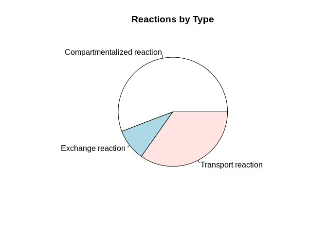

```r
pie(x = RECONcharacteristics$rType,
    main = "Reactions by Type"
    )
```

#### Reactions by Compartment

Compartmentalized reactions identified also are categorized and reported as a relative frequency to their associated compartment. To plot it just type:

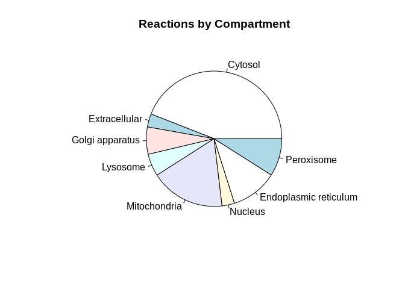

```r
pie(x = RECONcharacteristics$cReaction,
    main = "Reactions by Compartment",
    labels = compartmentNames
    )
```

#### Metabolites by Compartment

Metabolites are categorized and reported as a relative frequency to their associated compartment. To plot it just type:

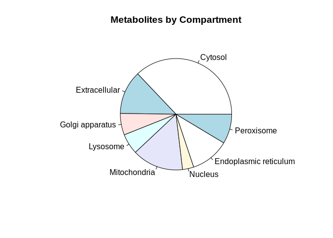

```r
pie(x = RECONcharacteristics$cMetabolites,
    main = "Metabolites by Compartment",
    labels = compartmentNames
    )
```